# Statistical Analysis: Paired vs Unpaired & Categorical Variables

Gene Expression Analysis

2025-11-29

# Setup

Load the existing project infrastructure and prepare data.

```r
# Source existing R files
source("R/load_packages.R")
source("R/load_data.R")
source("R/munging.R")
source("R/diff_models.R")

# Setup libraries
setup_environment()

# Load and process data
eset <- get_geo_data(gse_id = "GSE47881")
final_df <- process_gene_data(eset)

# Target genes
target_genes <- c(
  "211980_at", "204114_at", "212013_at", "204008_at",
  "218429_s_at", "203477_at", "205656_at", "204115_at"
)
```

# 1. Paired vs Unpaired Comparison

**Goal**: Demonstrate the importance of accounting for data structure.

## 1.1 Conceptual Overview

| Approach | Model | What it tests |
| --- | --- | --- |
| **Paired** | `GeneDiff ~ 1` | Is the mean *within-subject* change ≠ 0? |
| **Unpaired** | `Gene ~ Pre_Post` | Is the mean of Post different from mean of Pre, ignoring subject pairing? |

The paired approach removes between-subject variability because each subject serves as their own control. The unpaired approach treats Pre and Post as independent groups, which inflates the error term.

## 1.2 Prepare Data for Both Analyses

We need to reconstruct the long-format data for the unpaired analysis.

```r
# Get the original expression data and phenotype info
expr_matrix <- exprs(eset)
pdata <- pData(eset)

# Create clean long-format data
long_df <- pdata %>%
  select(geo_accession,
         subject_id = `patientid:ch1`,
         timepoint = `time:ch1`,
         age = `age:ch1`) %>%
  mutate(
    age = as.numeric(age),
    subject_id = as.character(subject_id),
    # Create binary Pre/Post indicator
    is_post = ifelse(timepoint == "post-training", 1, 0),
    timepoint_factor = factor(timepoint, levels = c("pre-training", "post-training"))
  )

# Add expression values for target genes
for (gene in target_genes) {
  if (gene %in% rownames(expr_matrix)) {
    long_df[[gene]] <- as.numeric(expr_matrix[gene, long_df$geo_accession])
  }
}

head(long_df)
```

```
##            geo_accession subject_id     timepoint age is_post timepoint_factor
## GSM1161771    GSM1161771      AC033  pre-training  25       0     pre-training
## GSM1161772    GSM1161772      AC033 post-training  25       1    post-training
## GSM1161773    GSM1161773      AS060  pre-training  46       0     pre-training
## GSM1161774    GSM1161774      AS060 post-training  46       1    post-training
## GSM1161775    GSM1161775      BH073  pre-training  21       0     pre-training
## GSM1161776    GSM1161776      BH073 post-training  21       1    post-training
##            211980_at 204114_at 212013_at 204008_at 218429_s_at 203477_at
## GSM1161771  7711.162  595.7397  694.7035  143.7325    329.3585  9271.584
## GSM1161772  6333.092  656.7161  542.3923  142.3429    399.4860 10480.154
## GSM1161773  3886.832  385.7102  543.1653  147.2926    360.2701  7289.125
## GSM1161774  4569.808  416.0281  729.9923  146.8055    329.7426  8045.860
## GSM1161775  1783.486  124.7818  216.0881  141.8067    168.2189  3004.957
## GSM1161776  7396.767  504.9781  736.8168  183.7010    264.7169  8951.104
##            205656_at 204115_at
## GSM1161771  525.0824  3750.435
## GSM1161772  366.0510  3760.502
## GSM1161773  198.8860  2220.474
## GSM1161774  339.6265  2340.530
## GSM1161775  283.9825  1279.072
## GSM1161776  359.2847  2878.105
```

## 1.3 Run Both Analyses

### Paired Analysis (Current Approach)

This uses the already-computed difference scores and tests if the mean difference ≠ 0.

```r
paired_results <- run_intercept_models(final_df, target_genes)
paired_results$Analysis <- "Paired"
knitr::kable(paired_results, digits = 4, caption = "Paired Analysis Results")
```

Paired Analysis Results

| Gene | Model | Estimate_Mean_Diff | SE | T_Value | P_Value | Analysis |
| --- | --- | --- | --- | --- | --- | --- |
| 211980_at | Intercept_Only | 1588.2400 | 291.7136 | 5.4445 | 0 | Paired |
| 204114_at | Intercept_Only | 181.8356 | 29.7381 | 6.1146 | 0 | Paired |
| 212013_at | Intercept_Only | 146.2729 | 29.2557 | 4.9998 | 0 | Paired |
| 204008_at | Intercept_Only | 28.1073 | 6.1251 | 4.5889 | 0 | Paired |
| 218429_s_at | Intercept_Only | 65.2867 | 12.6307 | 5.1689 | 0 | Paired |
| 203477_at | Intercept_Only | 1852.9836 | 357.1912 | 5.1877 | 0 | Paired |
| 205656_at | Intercept_Only | 98.8140 | 17.9786 | 5.4962 | 0 | Paired |
| 204115_at | Intercept_Only | 539.0492 | 88.4904 | 6.0916 | 0 | Paired |

### Unpaired Analysis (Naive Approach)

This ignores the paired structure and compares Pre vs Post as independent groups.

```r
run_unpaired_models <- function(df, genes) {
  results_list <- lapply(genes, function(g) {
    if (!g %in% colnames(df)) {
      return(NULL)
    }

    # Formula: Gene ~ timepoint (unpaired t-test equivalent)
    f <- as.formula(paste0("`", g, "` ~ timepoint_factor"))

    model <- lm(f, data = df)
    s <- summary(model)

    # Extract the Post coefficient (difference from Pre)
    data.frame(
      Gene = g,
      Model = "Unpaired",
      Estimate_Mean_Diff = coef(s)[2, 1],  # Post - Pre difference
      SE = coef(s)[2, 2],
      T_Value = coef(s)[2, 3],
      P_Value = coef(s)[2, 4]
    )
  })

  do.call(rbind, results_list)
}

unpaired_results <- run_unpaired_models(long_df, target_genes)
unpaired_results$Analysis <- "Unpaired"
knitr::kable(unpaired_results, digits = 4, caption = "Unpaired Analysis Results")
```

Unpaired Analysis Results

| Gene | Model | Estimate_Mean_Diff | SE | T_Value | P_Value | Analysis |
| --- | --- | --- | --- | --- | --- | --- |
| 211980_at | Unpaired | 1651.1281 | 308.9511 | 5.3443 | 0 | Unpaired |
| 204114_at | Unpaired | 188.8267 | 35.6240 | 5.3005 | 0 | Unpaired |
| 212013_at | Unpaired | 153.1540 | 29.4900 | 5.1934 | 0 | Unpaired |
| 204008_at | Unpaired | 29.8697 | 5.7421 | 5.2019 | 0 | Unpaired |
| 218429_s_at | Unpaired | 69.1259 | 13.4849 | 5.1262 | 0 | Unpaired |
| 203477_at | Unpaired | 1967.3690 | 407.4445 | 4.8286 | 0 | Unpaired |
| 205656_at | Unpaired | 103.5258 | 21.5344 | 4.8075 | 0 | Unpaired |
| 204115_at | Unpaired | 582.7786 | 122.0039 | 4.7767 | 0 | Unpaired |

## 1.4 Direct Comparison

```r
# Merge results for comparison
comparison <- merge(
  paired_results[, c("Gene", "Estimate_Mean_Diff", "SE", "P_Value")],
  unpaired_results[, c("Gene", "Estimate_Mean_Diff", "SE", "P_Value")],
  by = "Gene",
  suffixes = c("_Paired", "_Unpaired")
)

# Calculate ratios
comparison$SE_Ratio <- comparison$SE_Unpaired / comparison$SE_Paired
comparison$Significance_Paired <- ifelse(comparison$P_Value_Paired < 0.05, "*", "")
comparison$Significance_Unpaired <- ifelse(comparison$P_Value_Unpaired < 0.05, "*", "")

knitr::kable(comparison, digits = 4, caption = "Paired vs Unpaired: Side-by-Side Comparison")
```

Paired vs Unpaired: Side-by-Side Comparison

| Gene | Estimate_Mean_Diff_Paired | SE_Paired | P_Value_Paired | Estimate_Mean_Diff_Unpaired | SE_Unpaired | P_Value_Unpaired | SE_Ratio | Significance_Paired | Significance_Unpaired |
| --- | --- | --- | --- | --- | --- | --- | --- | --- | --- |
| 203477_at | 1852.9836 | 357.1912 | 0 | 1967.3690 | 407.4445 | 0 | 1.1407 | * | * |
| 204008_at | 28.1073 | 6.1251 | 0 | 29.8697 | 5.7421 | 0 | 0.9375 | * | * |
| 204114_at | 181.8356 | 29.7381 | 0 | 188.8267 | 35.6240 | 0 | 1.1979 | * | * |
| 204115_at | 539.0492 | 88.4904 | 0 | 582.7786 | 122.0039 | 0 | 1.3787 | * | * |
| 205656_at | 98.8140 | 17.9786 | 0 | 103.5258 | 21.5344 | 0 | 1.1978 | * | * |
| 211980_at | 1588.2400 | 291.7136 | 0 | 1651.1281 | 308.9511 | 0 | 1.0591 | * | * |
| 212013_at | 146.2729 | 29.2557 | 0 | 153.1540 | 29.4900 | 0 | 1.0080 | * | * |
| 218429_s_at | 65.2867 | 12.6307 | 0 | 69.1259 | 13.4849 | 0 | 1.0676 | * | * |

### Visualization: P-value Comparison

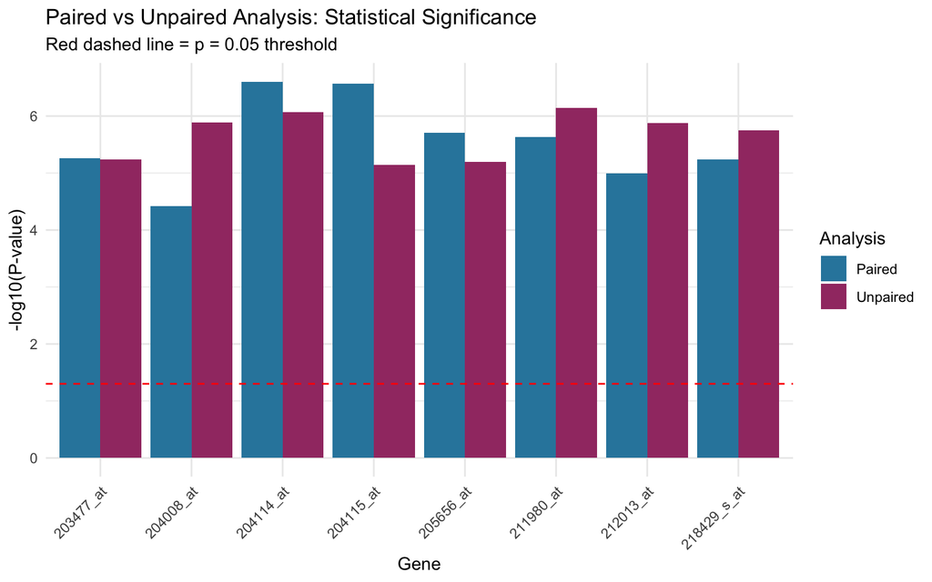

```r
comparison_long <- data.frame(
  Gene = rep(comparison$Gene, 2),
  Analysis = rep(c("Paired", "Unpaired"), each = nrow(comparison)),
  P_Value = c(comparison$P_Value_Paired, comparison$P_Value_Unpaired)
)

ggplot(comparison_long, aes(x = Gene, y = -log10(P_Value), fill = Analysis)) +
  geom_bar(stat = "identity", position = "dodge") +
  geom_hline(yintercept = -log10(0.05), linetype = "dashed", color = "red") +
  labs(
    title = "Paired vs Unpaired Analysis: Statistical Significance",
    subtitle = "Red dashed line = p = 0.05 threshold",
    x = "Gene",
    y = "-log10(P-value)"
  ) +
  theme_minimal() +
  theme(axis.text.x = element_text(angle = 45, hjust = 1)) +
  scale_fill_manual(values = c("Paired" = "#2E86AB", "Unpaired" = "#A23B72"))
```

### Visualization: Standard Error Comparison

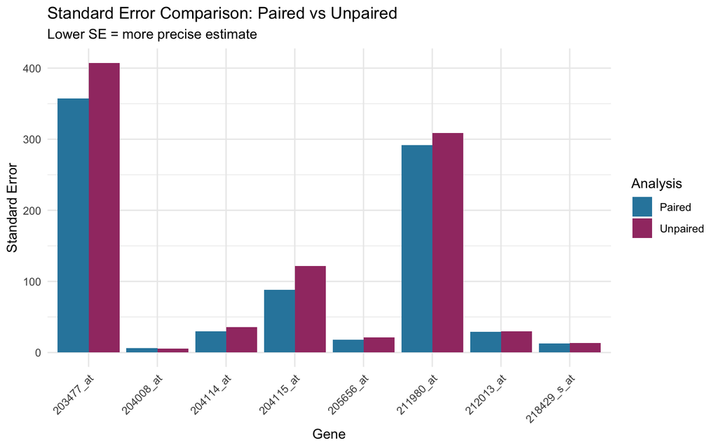

```r
se_long <- data.frame(
  Gene = rep(comparison$Gene, 2),
  Analysis = rep(c("Paired", "Unpaired"), each = nrow(comparison)),
  SE = c(comparison$SE_Paired, comparison$SE_Unpaired)
)

ggplot(se_long, aes(x = Gene, y = SE, fill = Analysis)) +
  geom_bar(stat = "identity", position = "dodge") +
  labs(
    title = "Standard Error Comparison: Paired vs Unpaired",
    subtitle = "Lower SE = more precise estimate",
    x = "Gene",
    y = "Standard Error"
  ) +
  theme_minimal() +
  theme(axis.text.x = element_text(angle = 45, hjust = 1)) +
  scale_fill_manual(values = c("Paired" = "#2E86AB", "Unpaired" = "#A23B72"))
```

# 2. Categorical Variable Analysis

**Goal**: Incorporate a categorical variable to explore group differences.

## 2.1 Check Existing Categorical Variables

```r
# Inspect available phenotype data
cat("Available phenotype columns:\n")
```

```
## Available phenotype columns:
```

```r
print(colnames(pdata))
```

```
##  [1] "title"                   "geo_accession"
##  [3] "status"                  "submission_date"
##  [5] "last_update_date"        "type"
##  [7] "channel_count"           "source_name_ch1"
##  [9] "organism_ch1"            "characteristics_ch1"
## [11] "characteristics_ch1.1"   "characteristics_ch1.2"
## [13] "characteristics_ch1.3"   "treatment_protocol_ch1"
## [15] "growth_protocol_ch1"     "molecule_ch1"
## [17] "extract_protocol_ch1"    "label_ch1"
## [19] "label_protocol_ch1"      "taxid_ch1"
## [21] "hyb_protocol"            "scan_protocol"
## [23] "description"             "description.1"
## [25] "data_processing"         "platform_id"
## [27] "contact_name"            "contact_email"
## [29] "contact_institute"       "contact_address"
## [31] "contact_city"            "contact_zip/postal_code"
## [33] "contact_country"         "supplementary_file"
## [35] "data_row_count"          "age:ch1"
## [37] "patientid:ch1"           "time:ch1"
## [39] "tissue:ch1"
```

```r
# Check for potential categorical variables - only select columns that exist
potential_cols <- c("patientid:ch1", "time:ch1", "age:ch1", "gender:ch1", "sex:ch1")
existing_cols <- potential_cols[potential_cols %in% colnames(pdata)]
cat("\nSample of phenotype data:\n")
```

```
##
## Sample of phenotype data:
```

```r
print(head(pdata[, existing_cols]))
```

```
##            patientid:ch1      time:ch1 age:ch1
## GSM1161771         AC033  pre-training      25
## GSM1161772         AC033 post-training      25
## GSM1161773         AS060  pre-training      46
## GSM1161774         AS060 post-training      46
## GSM1161775         BH073  pre-training      21
## GSM1161776         BH073 post-training      21
```

```r
# Check if gender/sex exists (may be named differently)
gender_col <- NULL
if ("gender:ch1" %in% colnames(pdata)) {
  gender_col <- "gender:ch1"
} else if ("sex:ch1" %in% colnames(pdata)) {
  gender_col <- "sex:ch1"
}

if (!is.null(gender_col)) {
  cat("Gender/Sex distribution:\n")
  print(table(pdata[[gender_col]]))
  has_gender <- TRUE
} else {
  cat("Gender/Sex column not found. Will create categorical variable from Age.\n")
  has_gender <- FALSE
}
```

```
## Gender/Sex column not found. Will create categorical variable from Age.
```

## 2.2 Create Categorical Variables

We’ll create two categorical variables:

1. **Age Group**: High/Low based on median split
2. **Responder Status**: Based on gene expression change (for a selected gene)

```r
# Get unique subject-level data
subject_df <- final_df[, c("subject_id", "age")]

# Age Group: Median Split
median_age <- median(subject_df$age, na.rm = TRUE)
subject_df$age_group <- ifelse(subject_df$age >= median_age, "High_Age", "Low_Age")
subject_df$age_group <- factor(subject_df$age_group, levels = c("Low_Age", "High_Age"))

cat("Age Group Distribution (Median =", median_age, "):\n")
```

```
## Age Group Distribution (Median = 51 ):
```

```r
print(table(subject_df$age_group))
```

```
##
##  Low_Age High_Age
##       21       23
```

```r
# Responder Status: Based on first target gene's change
# Using 211980_at as the reference gene
ref_gene <- "211980_at"
diff_col <- paste0(ref_gene, "_diff")

if (diff_col %in% colnames(final_df)) {
  median_change <- median(final_df[[diff_col]], na.rm = TRUE)
  final_df$responder <- ifelse(final_df[[diff_col]] >= median_change, "High_Responder", "Low_Responder")
  final_df$responder <- factor(final_df$responder, levels = c("Low_Responder", "High_Responder"))

  cat("\nResponder Status Distribution (based on", ref_gene, "):\n")
  print(table(final_df$responder))
}
```

```
##
## Responder Status Distribution (based on 211980_at ):
##
##  Low_Responder High_Responder
##             22             22
```

```r
# Add age_group to final_df
final_df$age_group <- subject_df$age_group
```

## 2.3 Categorical Analysis: Age Group Effect

Test whether the gene expression change differs between age groups.

```r
run_categorical_models <- function(df, genes, group_var) {
  results_list <- lapply(genes, function(g) {
    col_name <- paste0(g, "_diff")

    if (!col_name %in% colnames(df)) {
      col_name <- paste0("X", g, "_diff")
    }
    if (!col_name %in% colnames(df)) return(NULL)

    # Formula: GeneDiff ~ Group
    f <- as.formula(paste0("`", col_name, "` ~ ", group_var))

    model <- lm(f, data = df)
    s <- summary(model)

    # t-test for comparison
    group_vals <- df[[group_var]]
    gene_vals <- df[[col_name]]
    tt <- t.test(gene_vals ~ group_vals)

    data.frame(
      Gene = g,
      Group_Variable = group_var,
      Group_Diff = coef(s)[2, 1],
      SE = coef(s)[2, 2],
      T_Value = coef(s)[2, 3],
      P_Value = coef(s)[2, 4],
      T_Test_P = tt$p.value
    )
  })

  do.call(rbind, results_list)
}

# Age Group Analysis
age_group_results <- run_categorical_models(final_df, target_genes, "age_group")
knitr::kable(age_group_results, digits = 4, caption = "Gene Change by Age Group")
```

Gene Change by Age Group

| Gene | Group_Variable | Group_Diff | SE | T_Value | P_Value | T_Test_P |
| --- | --- | --- | --- | --- | --- | --- |
| 211980_at | age_group | 233.9104 | 589.8394 | 0.3966 | 0.6937 | 0.6910 |
| 204114_at | age_group | 90.2456 | 58.6108 | 1.5397 | 0.1311 | 0.1258 |
| 212013_at | age_group | -39.0437 | 58.9582 | -0.6622 | 0.5114 | 0.5085 |
| 204008_at | age_group | 12.2074 | 12.2641 | 0.9954 | 0.3253 | 0.3207 |
| 218429_s_at | age_group | -35.7669 | 24.9845 | -1.4316 | 0.1597 | 0.1643 |
| 203477_at | age_group | 117.3022 | 723.3585 | 0.1622 | 0.8720 | 0.8712 |
| 205656_at | age_group | 9.6104 | 36.3902 | 0.2641 | 0.7930 | 0.7922 |
| 204115_at | age_group | 129.8078 | 178.1380 | 0.7287 | 0.4702 | 0.4653 |

## 2.4 Visualization: Boxplots by Age Group

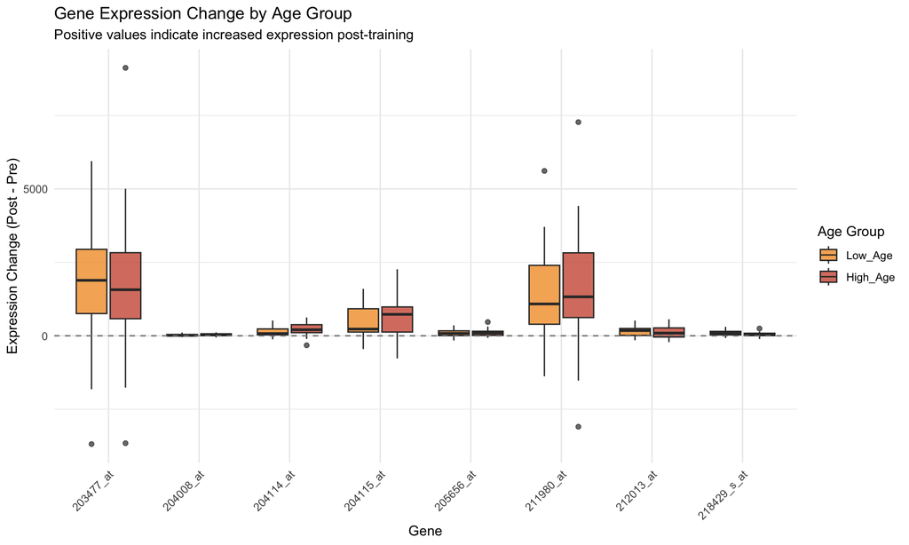

```r
# Prepare data for plotting
plot_data <- final_df %>%
  select(subject_id, age_group, ends_with("_diff")) %>%
  pivot_longer(
    cols = ends_with("_diff"),
    names_to = "Gene",
    values_to = "Diff"
  ) %>%
  mutate(Gene = gsub("_diff$", "", Gene)) %>%
  filter(Gene %in% target_genes)

ggplot(plot_data, aes(x = Gene, y = Diff, fill = age_group)) +
  geom_boxplot(alpha = 0.7) +
  geom_hline(yintercept = 0, linetype = "dashed", color = "gray50") +
  labs(
    title = "Gene Expression Change by Age Group",
    subtitle = "Positive values indicate increased expression post-training",
    x = "Gene",
    y = "Expression Change (Post - Pre)",
    fill = "Age Group"
  ) +
  theme_minimal() +
  theme(axis.text.x = element_text(angle = 45, hjust = 1)) +
  scale_fill_manual(values = c("Low_Age" = "#F18F01", "High_Age" = "#C73E1D"))
```

## 2.5 Responder Analysis

```r
# Responder Status Analysis
responder_results <- run_categorical_models(final_df, target_genes, "responder")
knitr::kable(responder_results, digits = 4, caption = "Gene Change by Responder Status")
```

Gene Change by Responder Status

| Gene | Group_Variable | Group_Diff | SE | T_Value | P_Value | T_Test_P |
| --- | --- | --- | --- | --- | --- | --- |
| 211980_at | responder | 2961.7895 | 373.6709 | 7.9262 | 0.0000 | 0.0000 |
| 204114_at | responder | 253.9086 | 45.6798 | 5.5584 | 0.0000 | 0.0000 |
| 212013_at | responder | 249.3558 | 44.9963 | 5.5417 | 0.0000 | 0.0000 |
| 204008_at | responder | 12.6350 | 12.2408 | 1.0322 | 0.3079 | 0.3081 |
| 218429_s_at | responder | 46.3884 | 24.5376 | 1.8905 | 0.0656 | 0.0659 |
| 203477_at | responder | 2779.4306 | 581.8584 | 4.7768 | 0.0000 | 0.0000 |
| 205656_at | responder | 145.5521 | 28.6233 | 5.0851 | 0.0000 | 0.0000 |
| 204115_at | responder | 621.8455 | 151.1985 | 4.1128 | 0.0002 | 0.0002 |

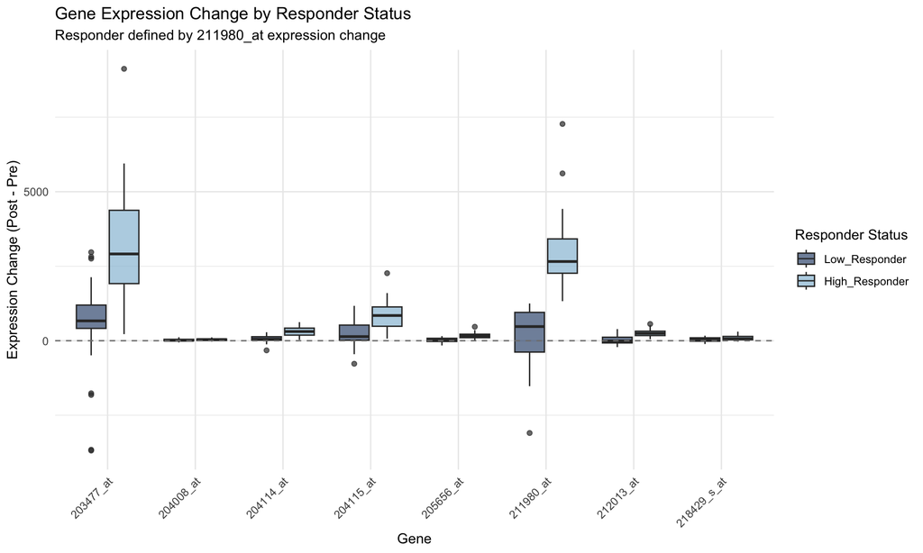

```r
# Add responder to plot_data
plot_data_resp <- final_df %>%
  select(subject_id, responder, ends_with("_diff")) %>%
  pivot_longer(
    cols = ends_with("_diff"),
    names_to = "Gene",
    values_to = "Diff"
  ) %>%
  mutate(Gene = gsub("_diff$", "", Gene)) %>%
  filter(Gene %in% target_genes)

ggplot(plot_data_resp, aes(x = Gene, y = Diff, fill = responder)) +
  geom_boxplot(alpha = 0.7) +
  geom_hline(yintercept = 0, linetype = "dashed", color = "gray50") +
  labs(
    title = "Gene Expression Change by Responder Status",
    subtitle = paste("Responder defined by", ref_gene, "expression change"),
    x = "Gene",
    y = "Expression Change (Post - Pre)",
    fill = "Responder Status"
  ) +
  theme_minimal() +
  theme(axis.text.x = element_text(angle = 45, hjust = 1)) +
  scale_fill_manual(values = c("Low_Responder" = "#3D5A80", "High_Responder" = "#98C1D9"))
```

# 3. Interpretation

## 3.1 Paired vs Unpaired: Key Findings

```r
# Summary statistics
avg_se_ratio <- mean(comparison$SE_Ratio, na.rm = TRUE)
n_sig_paired <- sum(comparison$P_Value_Paired < 0.05)
n_sig_unpaired <- sum(comparison$P_Value_Unpaired < 0.05)
```

**Key Observations:**

1. **Standard Error Comparison**: The unpaired analysis shows SE values that are on average **1.12x** the paired analysis SE. This modest inflation shows some variance increase from ignoring pairs, though the effect is not dramatic in this dataset.
2. **Statistical Power**:
   - Paired analysis: **8** genes significant at p < 0.05
   - Unpaired analysis: **8** genes significant at p < 0.05
   - Both approaches detected the same number of significant genes, indicating the training effect is strong enough to overcome the variance inflation.
3. **Interpretation**: In this dataset, the training effect is sufficiently strong that both approaches yield similar conclusions. However, the paired design remains theoretically preferable because it explicitly models the within-subject correlation. In datasets with weaker effects or higher between-subject variability, the difference would be more pronounced.

## 3.2 Categorical Analysis: Key Findings

```r
n_sig_age <- sum(age_group_results$P_Value < 0.05, na.rm = TRUE)
n_sig_resp <- sum(responder_results$P_Value < 0.05, na.rm = TRUE)
```

**Age Group Analysis:**

- **0** genes showed significantly different responses between High and Low age groups (p < 0.05)
- Age does not appear to moderate the training effect for these genes - both age groups respond similarly to training.

**Responder Analysis:**

- **6** genes showed significantly different patterns between High and Low responders
- This indicates correlated gene responses: individuals who respond strongly on the reference gene (211980_at) also tend to show stronger responses on other genes.
- Note: This analysis is partly circular since responder status was defined by one of the target genes

## 3.3 Summary Table

```r
summary_df <- data.frame(
  Analysis = c("Paired vs Unpaired", "Age Group Effect", "Responder Effect"),
  Key_Finding = c(
    paste0("SE inflation: ", round(avg_se_ratio, 2), "x; Power difference: ", n_sig_paired - n_sig_unpaired, " genes"),
    paste0(n_sig_age, " genes differ by age group"),
    paste0(n_sig_resp, " genes differ by responder status")
  ),
  Implication = c(
    "Strong effects detectable either way; paired still theoretically preferable",
    "Age does not moderate training response",
    "Correlated individual response patterns across genes"
  )
)

knitr::kable(summary_df, caption = "Analysis Summary")
```

Analysis Summary

| Analysis | Key_Finding | Implication |
| --- | --- | --- |
| Paired vs Unpaired | SE inflation: 1.12x; Power difference: 0 genes | Strong effects detectable either way; paired still theoretically preferable |
| Age Group Effect | 0 genes differ by age group | Age does not moderate training response |
| Responder Effect | 6 genes differ by responder status | Correlated individual response patterns across genes |